# Delegation as a Prosocial Act under Social Awareness: Revisiting the Intrinsic Value of Decision Rights

Tomo OKADA, Masao NAGATSUKA, and Toshihiko NANBA

- This file reproduces the main results, figures, and appendix tables reported in the manuscript.

### Load required packages

```r
library(tidyverse)
library(zTree)
library(DT)
library(here)
library(fixest)
library(modelsummary)
library(readxl)
```

### Load the original data from Bartling et al. (2014)

- The results differ slightly from those reported in the paper, possibly because the session on 121206 contains missing values.

```r
bfsdata <- read.csv(here("data", "Bartling_original", "Bartling_original.csv")) %>%
  filter(maecontrol == 0,
         type == "Principal")

datatable(
  bfsdata,
  extensions = "Scroller",
  options = list(
    deferRender = TRUE,
    scrollY = 200,
    scrollX = TRUE,
    scroller = TRUE
  )
)
```

|  | subject | situation | sessionid | finalprofit | showupfee | type | period_game | aeffort | peffort | mae | varianta | variantp | period_lottery | period_lottery_del | offeraccept | offeracceptd | IV | va | vb | vc | vd | consistent | lossaversion | ioc | eopt | maeopt | cost | EV_control | EV_deleg | … |
| --- | --- | --- | --- | --- | --- | --- | --- | --- | --- | --- | --- | --- | --- | --- | --- | --- | --- | --- | --- | --- | --- | --- | --- | --- | --- | --- | --- | --- | --- | --- |
| 1 | 1 | 1 | 111017_1315 | 59.634602 | 10 | Principal | 9 | 100 | 97 | 1 | 2 | 1 | 15 | 14 | 120 | 150 | 30 | 220 | 220 | 190 | 100 | 1 | -1 | 0 | 60 | 40 | 94.089996 | 122.31 | 100.9 | … |
| 2 | 1 | 2 | 111017_1315 | 59.634602 | 10 | Principal | 2 | 0 | 85 | 1 | 1 | 1 | 11 | 8 | 180 | 120 | -60 | 280 | 280 | 235 | 100 | 1 | -1 | 0 | 90 | 60 | 72.25 | 180.75 | 101.35 | … |
| 3 | 1 | 3 | 111017_1315 | 59.634602 | 10 | Principal | 10 | 29 | 78 | 63 | 2 | 1 | 17 | 19 | 90 | 120 | 30 | 180 | 180 | 140 | 100 | 1 | -1 | 0 | 40 | 40 | 60.84 | 101.56 | 125.2 | … |
| 4 | 1 | 4 | 111017_1315 | 59.634602 | 10 | Principal | 7 | 44 | 97 | 77 | 2 | 1 | 2 | 10 | 120 | 140 | 20 | 220 | 220 | 160 | 100 | 1 | -1 | 0 | 60 | 60 | 94.089996 | 122.31 | 146.2 | … |
| 5 | 1 | 5 | 111017_1315 | 59.634602 | 10 | Principal | 3 | 51 | 97 | 95 | 2 | 1 | 3 | 16 | 150 | 250 | 100 | 260 | 260 | 260 | 100 | 1 | -1 | 0 | 80 | 40 | 94.089996 | 161.11 | 252 | … |
| 6 | 1 | 6 | 111017_1315 | 59.634602 | 10 | Principal | 4 | 85 | 97 | 1 | 2 | 1 | 7 | 4 | 225 | 200 | -25 | 440 | 440 | 380 | 200 | 1 | -1 | 0 | 60 | 40 | 188.17999 | 244.62 | 201.8 | … |
| 7 | 1 | 7 | 111017_1315 | 59.634602 | 10 | Principal | 1 | 75 | 95 | 67 | 2 | 1 | 13 | 5 | 360 | 400 | 40 | 560 | 560 | 470 | 200 | 1 | -1 | 0 | 90 | 60 | 180.5 | 361.5 | 380.89999 | … |
| 8 | 1 | 8 | 111017_1315 | 59.634602 | 10 | Principal | 6 | 63 | 84 | 63 | 2 | 1 | 20 | 12 | 195 | 240 | 45 | 360 | 360 | 280 | 200 | 1 | -1 | 0 | 40 | 40 | 141.12 | 193.28 | 250.39999 | … |
| 9 | 1 | 9 | 111017_1315 | 59.634602 | 10 | Principal | 8 | 70 | 77 | 77 | 2 | 1 | 9 | 6 | 250 | 280 | 30 | 440 | 440 | 320 | 200 | 1 | -1 | 0 | 60 | 60 | 118.58 | 266.22 | 292.39999 | … |
| 10 | 1 | 10 | 111017_1315 | 59.634602 | 10 | Principal | 5 | 100 | 90 | 90 | 1 | 1 | 18 | 1 | 340 | 480 | 140 | 520 | 520 | 520 | 200 | 1 | -1 | 0 | 80 | 40 | 162 | 326 | 488 | … |

[output cut: 680 more lines]

### Function for processing experimental data

```r
bartling <- function(file_path) {

  data <- zTreeTables(file_path, ignore.errors = TRUE)

  #-----------------------------
  # Global data
  #-----------------------------
  data_global <-
    data$globals %>%
    filter(Treatment == 1) %>%
    rename_all(gsub, pattern = "+\\[", replacement = "_") %>%
    rename_all(gsub, pattern = "]", replacement = "")

  #-----------------------------
  # Subject-level data
  #-----------------------------
  data_subjects <- data$subjects

  #-----------------------------
  # Questionnaire data
  #-----------------------------
  questionnaire <-
    readxl::read_excel(here("data", "Quesstionnaire.xlsx")) %>%
    select(
      sessionid = session_id,
      subject,
      female,
      economics,
      q_gaze_next = q2_8,
      q_gaze_nearby = q2_9,
      q_gaze_experimenter = q2_10,
      q_analyzed_by_experimenter = q2_11
    ) %>%
    mutate(
      sessionid = as.character(sessionid),
      subject = as.numeric(subject)
    )

  #-----------------------------
  # Final profit
  #-----------------------------
  finalprofit <-
    data_subjects %>%
    filter(Treatment == max(Treatment)) %>%
    select(finalprofit = Profitm, subject = Subject)

  #-----------------------------
  # Loss gamble / IoC
  #-----------------------------
  loss_ioc <-
    data_subjects %>%
    filter(Treatment == 4) %>%
    transmute(
      subject = Subject,
      lossgamble = lossgamble,
      IoC = IoC
    ) %>%
    distinct()

  #-----------------------------
  # Part 1
  #-----------------------------
  data1 <-
    data_subjects %>%
    filter(Treatment == 1) %>%
    rename_all(gsub, pattern = "+\\[", replacement = "_") %>%
    rename_all(gsub, pattern = "]", replacement = "") %>%
    mutate(
      showupfee = 1200,
      type = ifelse(Type == 1, "Principal", "Agent")
    ) %>%
    relocate(Treatment, subject = Subject, sessionid = Date, showupfee, type) %>%
    {
      if ("Group_1" %in% names(.)) select(., !Group_1:ncol(.)) else .
    } %>%
    select(!Period:slow) %>%
    inner_join(finalprofit, by = "subject")

  #-----------------------------
  # Reshape Part 1 into tidy format
  #-----------------------------
  data1 <- data1 %>%
    pivot_longer(
      !c(subject, sessionid, finalprofit, showupfee, type, Treatment),
      names_to = c(".value", "situation"),
      names_sep = "_"
    ) %>%
    mutate(
      period_game = case_when(
        situation == 1 ~ data_global$O_1,
        situation == 2 ~ data_global$O_2,
        situation == 3 ~ data_global$O_3,
        situation == 4 ~ data_global$O_4,
        situation == 5 ~ data_global$O_5,
        situation == 6 ~ data_global$O_6,
        situation == 7 ~ data_global$O_7,
        situation == 8 ~ data_global$O_8,
        situation == 9 ~ data_global$O_9,
        situation == 10 ~ data_global$O_10
      ),
      va = case_when(
        situation == 1 ~ data_global$VA_1,
        situation == 2 ~ data_global$VA_2,
        situation == 3 ~ data_global$VA_3,
        situation == 4 ~ data_global$VA_4,
        situation == 5 ~ data_global$VA_5,
        situation == 6 ~ data_global$VA_6,
        situation == 7 ~ data_global$VA_7,
        situation == 8 ~ data_global$VA_8,
        situation == 9 ~ data_global$VA_9,
        situation == 10 ~ data_global$VA_10
      ),
      vb = case_when(
        situation == 1 ~ data_global$VB_1,
        situation == 2 ~ data_global$VB_2,
        situation == 3 ~ data_global$VB_3,
        situation == 4 ~ data_global$VB_4,
        situation == 5 ~ data_global$VB_5,
        situation == 6 ~ data_global$VB_6,
        situation == 7 ~ data_global$VB_7,
        situation == 8 ~ data_global$VB_8,
        situation == 9 ~ data_global$VB_9,
        situation == 10 ~ data_global$VB_10
      ),
      vc = case_when(
        situation == 1 ~ data_global$VC_1,
        situation == 2 ~ data_global$VC_2,
        situation == 3 ~ data_global$VC_3,
        situation == 4 ~ data_global$VC_4,
        situation == 5 ~ data_global$VC_5,
        situation == 6 ~ data_global$VC_6,
        situation == 7 ~ data_global$VC_7,
        situation == 8 ~ data_global$VC_8,
        situation == 9 ~ data_global$VC_9,
        situation == 10 ~ data_global$VC_10
      ),
      vd = case_when(
        situation == 1 ~ data_global$VD_1,
        situation == 2 ~ data_global$VD_2,
        situation == 3 ~ data_global$VD_3,
        situation == 4 ~ data_global$VD_4,
        situation == 5 ~ data_global$VD_5,
        situation == 6 ~ data_global$VD_6,
        situation == 7 ~ data_global$VD_7,
        situation == 8 ~ data_global$VD_8,
        situation == 9 ~ data_global$VD_9,
        situation == 10 ~ data_global$VD_10
      ),
      stakesize = ifelse(situation <= 5, "low",
                  ifelse(situation >= 6, "high", NA)),
      conflict = ifelse(situation == 1, "0.75(Low)",
                 ifelse(situation == 2, "0.75(Low)",
                 ifelse(situation == 3, "0.5(High)",
                 ifelse(situation == 4, "0.5(High)",
                 ifelse(situation == 5, "1(No)",
                 ifelse(situation == 6, "0.75(Low)",
                 ifelse(situation == 7, "0.75(Low)",
                 ifelse(situation == 8, "0.5(High)",
                 ifelse(situation == 9, "0.5(High)",
                 ifelse(situation == 10, "1(No)", NA)))))))))),
      cost = ifelse(type == "Principal", pcost, acost),
      situation = as.numeric(situation)
    ) %>%
    relocate(
      c(sessionid, subject, situation,
        finalprofit, showupfee, type,
        period_game, aeffort, peffort,
        mae = MAE, varianta = VariantA,
        variantp = VariantP)
    ) %>%
    select(!c(Treatment, acost, pcost))

  #-----------------------------
  # Part 2
  #-----------------------------
  data2 <- data_subjects %>%
    filter(Treatment == 2) %>%
    rename_all(gsub, pattern = "+\\[", replacement = "_") %>%
    rename_all(gsub, pattern = "]", replacement = "") %>%
    select(Subject, OL_1:offeraccept_20) %>%
    pivot_longer(
      -Subject,
      names_to = c(".value", "situation"),
      names_sep = "_"
    ) %>%
    mutate(situation = as.numeric(situation))

  data2_control_lottery <-
    data2 %>%
    filter(situation <= 10) %>%
    mutate(period_lottery = OL, subject = Subject) %>%
    select(!c(OL, Subject))

  data2_delegation_lottery <-
    data2 %>%
    filter(situation > 10) %>%
    mutate(situation = situation - 10) %>%
    select(
      period_lottery_del = OL,
      offeracceptd = offeraccept,
      subject = Subject,
      situation
    )

  data2 <-
    inner_join(
      data2_control_lottery,
      data2_delegation_lottery,
      by = c("subject", "situation")
    ) %>%
    relocate(period_lottery, period_lottery_del, offeraccept, offeracceptd) %>%
    filter(offeraccept != 0 & offeraccept != 1)

  #-----------------------------
  # Merge Part 1 and Part 2
  #-----------------------------
  x <-
    inner_join(data1, data2, by = c("subject", "situation")) %>%
    left_join(loss_ioc, by = "subject") %>%
    mutate(
      IV = ifelse(type == "Principal", offeracceptd - offeraccept, NA)
    ) %>%
    select(-j)

  #-----------------------------
  # Merge questionnaire data
  #-----------------------------
  x <-
    x %>%
    mutate(
      sessionid = as.character(sessionid),
      subject = as.numeric(subject)
    ) %>%
    left_join(questionnaire, by = c("sessionid", "subject"))

  return(x)
}
```

### Load and prepare the experimental data

**Treatment Description.**

- T1: Partitioned and unidentified counterpart
- T2: No partition and unidentified counterpart
- T3: Partitioned and identified counterpart
- T4: No partition and identified counterpart

**Participants: 324 subjects (3236 observations).**

- T1: 42 pairs (419 observations; 1 observation dropped because offeraccept was 0 or 1)
- T2: 39 pairs (387 observations; 3 observations dropped because offeraccept was 0 or 1)
- T3: 42 pairs (420 observations)
- T4: 39 pairs (390 observations)

```r
data %>%
  group_by(treatment) %>%
  summarise(
    total_obs = n()
  )
```

| treatment | total_obs |
| --- | --- |
| 1 | 419 |
| 2 | 387 |
| 3 | 420 |
| 4 | 390 |

- Display the dataset

```r
tidy_data %>%
  datatable(
    data =.,
    #filter = 'bottom',
    extensions = 'Scroller',
    options = list(
    deferRender = TRUE,
    scrollY = 200,
    scrollX = TRUE,
    scroller = TRUE
  ))
```

|  | treatment | sessionid | subject | situation | finalprofit | showupfee | type | period_game | aeffort | peffort | mae | varianta | variantp | va | vb | vc | vd | stakesize | conflict | cost | period_lottery | period_lottery_del | offeraccept | offeracceptd | lossgamble | IoC | IV | female | economics | … |
| --- | --- | --- | --- | --- | --- | --- | --- | --- | --- | --- | --- | --- | --- | --- | --- | --- | --- | --- | --- | --- | --- | --- | --- | --- | --- | --- | --- | --- | --- | --- |
| 1 | 1 | 211129_0916 | 1 | 1 | 780.64 | 1200 | Principal | 7 | 69 | 54 | 10 | 2 | 1 | 220 | 220 | 190 | 100 | low | 0.75(Low) | 58.32 | 5 | 12 | 140 | 110 | 6 | 0 | -30 | 0 | 0 | … |
| 2 | 1 | 211129_0916 | 1 | 2 | 780.64 | 1200 | Principal | 6 | 49 | 44 | 15 | 2 | 1 | 280 | 280 | 235 | 100 | low | 0.75(Low) | 38.72 | 6 | 19 | 180 | 165 | 6 | 0 | -15 | 0 | 0 | … |
| 3 | 1 | 211129_0916 | 1 | 3 | 780.64 | 1200 | Principal | 9 | 59 | 44 | 10 | 2 | 1 | 180 | 180 | 140 | 100 | low | 0.5(High) | 38.72 | 20 | 10 | 110 | 100 | 6 | 0 | -10 | 0 | 0 | … |
| 4 | 1 | 211129_0916 | 1 | 4 | 780.64 | 1200 | Principal | 5 | 59 | 100 | 1 | 1 | 1 | 220 | 220 | 160 | 100 | low | 0.5(High) | 100 | 13 | 11 | 140 | 100 | 6 | 0 | -40 | 0 | 0 | … |
| 5 | 1 | 211129_0916 | 1 | 6 | 780.64 | 1200 | Principal | 4 | 59 | 44 | 10 | 2 | 1 | 440 | 440 | 380 | 200 | high | 0.75(Low) | 19.36 | 9 | 4 | 300 | 290 | 6 | 0 | -10 | 0 | 0 | … |
| 6 | 1 | 211129_0916 | 1 | 7 | 780.64 | 1200 | Principal | 2 | 59 | 60 | 10 | 2 | 1 | 560 | 560 | 470 | 200 | high | 0.75(Low) | 36 | 8 | 17 | 300 | 330 | 6 | 0 | 30 | 0 | 0 | … |
| 7 | 1 | 211129_0916 | 1 | 8 | 780.64 | 1200 | Principal | 1 | 55 | 44 | 10 | 2 | 1 | 360 | 360 | 280 | 200 | high | 0.5(High) | 19.36 | 18 | 15 | 142 | 200 | 6 | 0 | 58 | 0 | 0 | … |
| 8 | 1 | 211129_0916 | 1 | 9 | 780.64 | 1200 | Principal | 3 | 55 | 60 | 1 | 2 | 1 | 440 | 440 | 320 | 200 | high | 0.5(High) | 36 | 16 | 1 | 250 | 200 | 6 | 0 | -50 | 0 | 0 | … |
| 9 | 1 | 211129_0916 | 1 | 10 | 780.64 | 1200 | Principal | 10 | 79 | 31 | 32 | 1 | 1 | 520 | 520 | 520 | 200 | low | 1(No) | 19.22 | 14 | 2 | 300 | 200 | 6 | 0 | -100 | 0 | 0 | … |
| 10 | 1 | 211129_0916 | 2 | 1 | 749.98 | 1200 | Agent | 7 | 69 | 54 | 10 | 2 | 1 | 220 | 220 | 190 | 100 | low | 0.75(Low) | 95.22 | 17 | 12 | 130 | 120 | 2 | 0 |  |  |  | … |

[output cut: 3226 more lines]

### Analysis

#### 4.2 Intrinsic Value of Decision Rights (IV)

```r
# Function to create bar plots by treatment

treatment_bar <-
  function (df, var, num1, num2) {
      x <- df %>%
            group_by(treatment) %>%
            ggplot(aes(x= treatment,
                       y = {{ var }})) +
            coord_cartesian(ylim=c(num1, num2)) +
            stat_summary(geom = "col", fun = "mean", fill = "grey50", width = 0.5) +
            stat_summary( fun.data = "mean_se",
                          geom = "errorbar",
                          width = .2, color = "grey20") +
            theme_bw() +
            labs(x = "Treatment") +
            theme(axis.title.y = element_blank())

      return(x)
  }
```

- Descriptive statistics of IV by treatment, including Bartling et al. (2014)

```r
# Combine IV data from our experiment with Bartling et al. (2014)

data_main <- data %>%
  select(IV, mae, peffort, treatment)

bfsdata_main <- bfsdata %>%
  select(IV, mae, peffort) %>%
  mutate(treatment = "Bartling et al. (2014)")

data_main_joined <- rbind(data_main, bfsdata_main)

# Summary statistics by treatment
data_main_joined  %>%
  group_by(treatment) %>%
  summarise(
    mean_IV = mean(IV, na.rm = TRUE),
    sd_IV   = sd(IV, na.rm = TRUE),
    n       = sum(!is.na(IV)),
    se_IV   = sd_IV / sqrt(n)
  )
```

| treatment | mean_IV | sd_IV | n | se_IV |
| --- | --- | --- | --- | --- |
| 1 | 39.65871 | 75.36286 | 419 | 3.681717 |
| 2 | 25.87080 | 65.11058 | 387 | 3.309757 |
| 3 | 23.22857 | 64.02181 | 420 | 3.123945 |
| 4 | 19.43333 | 62.59651 | 390 | 3.169698 |
| Bartling et al. (2014) | 25.08406 | 58.34708 | 690 | 2.221235 |

- Measured intrinsic value of decision rights (IV) by treatment (Figure 2)

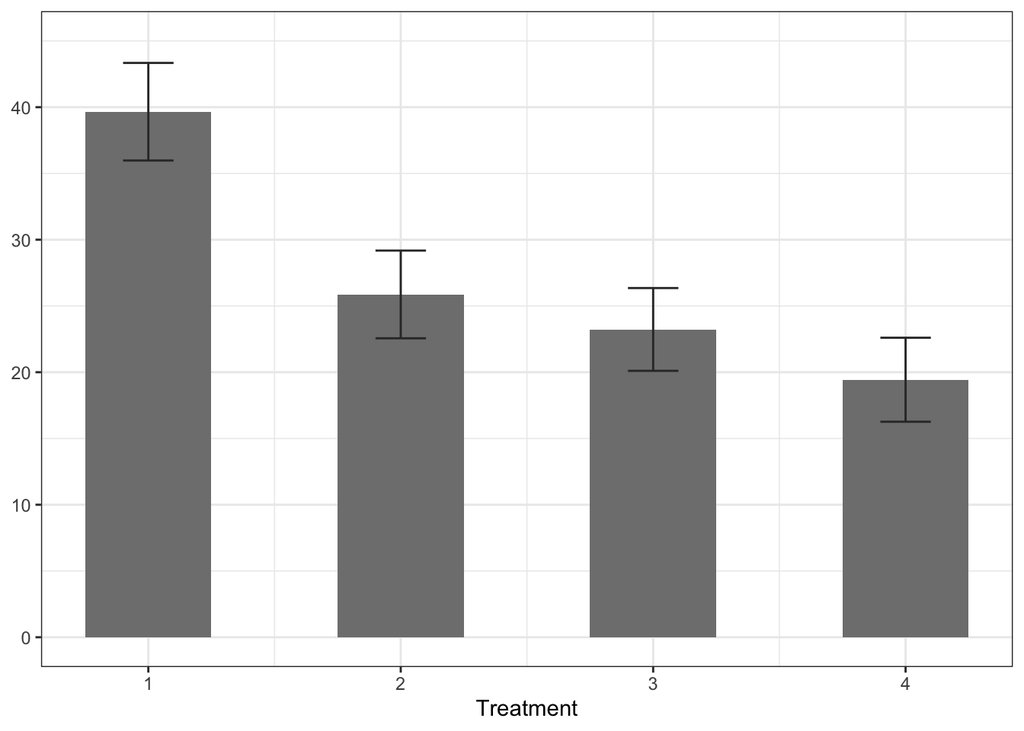

```r
# Bar plot of IV by treatment (with standard error bars)

data %>%
  treatment_bar(., IV, 0, 45)
```

**Measured IV: T1 vs T4**

- We first compare the measured intrinsic value of decision rights (IV) between T1 and T4 using a two-sided Wilcoxon rank-sum test.
- The null hypothesis of equal distributions is rejected ($W = 95{,}606$, $p < 0.001$).
- IV is significantly higher in T1 than in T4, consistent with H2P rather than H2R.

```r
# Extract observations for T1 and T4 only
df_T1T4 <- data %>%
  filter(treatment %in% c(1, 4)) %>%
  mutate(treatment = factor(treatment))

# Two-sided Wilcoxon rank-sum test
wilcox.test(
  IV ~ treatment,
  data = df_T1T4,
  exact = FALSE
)
```

```
##
##  Wilcoxon rank sum test with continuity correction
##
## data:  IV by treatment
## W = 95606, p-value = 2.761e-05
## alternative hypothesis: true location shift is not equal to 0
```

**Regression analysis for measured IV**

- We next estimate regression models for measured IV.
- Columns (1) and (2) use treatment indicators with T1 as the reference category.
- Columns (3) and (4) decompose the treatment effects into the two treatment dimensions: openness (open) and counterpart identification (identified).
- Following Ferreira et al. (2020), Columns (2) and (4) additionally control for gender, a dummy for students in Economics or Management, and behavioral measures from the Loss Aversion and Illusion of Control tasks.

```r
# Define treatment dimensions: openness (no partition) and counterpart identification
data <- data %>%
  mutate(
    open = ifelse(treatment %in% c(2, 4), 1, 0),
    identified = ifelse(treatment %in% c(3, 4), 1, 0)
  )

# Treatment-based specifications
res_tr1 <- feols(
  IV ~ i(treatment, ref = 1),
  data = data,
  cluster = "participant"
)

res_tr2 <- feols(
  IV ~ i(treatment, ref = 1) + lossgamble + IoC + female + economics,
  data = data,
  cluster = "participant"
)

# Mechanism-based specifications
res_mech1 <- feols(
  IV ~ open * identified,
  data = data,
  cluster = ~participant
)

res_mech2 <- feols(
  IV ~ open * identified + lossgamble + IoC + female + economics,
  data = data,
  cluster = ~participant
)

# Regression table (displayed and exported)
modelsummary(
  list(
    "(1) Treatment" = res_tr1,
    "(2) Treatment" = res_tr2,
    "(3) Mechanism" = res_mech1,
    "(4) Mechanism" = res_mech2
  ),
  coef_rename = c(
    "treatment::2" = "T2",
    "treatment::3" = "T3",
    "treatment::4" = "T4",
    "lossgamble" = "Loss Aversion",
    "IoC" = "Illusion of Control",
    "female" = "Female",
    "economics" = "Economics & Management"
  ),
  coef_order = c(
    "treatment::2",
    "treatment::3",
    "treatment::4",
    "open",
    "identified",
    "open:identified",
    "lossgamble",
    "IoC",
    "female",
    "economics"
  ),
  stars = c("*" = .1, "**" = .05, "***" = .01),
  statistic = "({std.error})",
  gof_omit = "IC|Log|Adj"
)
```

|  | (1) Treatment | (2) Treatment | (3) Mechanism | (4) Mechanism |
| --- | --- | --- | --- | --- |
| (Intercept) | 39.659*** | 36.058*** | 39.659*** | 36.058*** |
|  | (6.217) | (9.351) | (6.217) | (9.351) |
| T2 | -13.788* | -15.017* |  |  |
|  | (7.859) | (8.100) |  |  |
| T3 | -16.430** | -13.107* |  |  |
|  | (7.622) | (7.733) |  |  |
| T4 | -20.225*** | -18.779** |  |  |
|  | (7.275) | (7.383) |  |  |
| Loss Aversion |  | 0.467 |  | 0.467 |
|  |  | (1.307) |  | (1.307) |
| Illusion of Control |  | 0.013 |  | 0.013 |
|  |  | (0.333) |  | (0.333) |
| Female |  | -3.108 |  | -3.108 |
|  |  | (5.153) |  | (5.153) |
| Economics & Management |  | 16.542** |  | 16.542** |
|  |  | (6.885) |  | (6.885) |
| open |  |  | -13.788* | -15.017* |
|  |  |  | (7.859) | (8.100) |
| identified |  |  | -16.430** | -13.107* |
|  |  |  | (7.622) | (7.733) |
| open:identified |  |  | 9.993 | 9.345 |
|  |  |  | (9.771) | (9.834) |
| Num.Obs. | 1616 | 1576 | 1616 | 1576 |
| R2 | 0.013 | 0.021 | 0.013 | 0.021 |
| RMSE | 66.99 | 66.80 | 66.99 | 66.80 |
| Std.Errors | by: participant | by: participant | by: participant | by: participant |

* p < 0.1, ** p < 0.05, *** p < 0.01

**H3 test: positivity of IV in all treatments**

- Finally, we test Hypothesis 3 by examining whether the mean measured IV is significantly greater than zero in each treatment.
- We report the treatment-level mean IV, the raw p-value from a one-sample t-test against zero, and the Bonferroni-adjusted p-value.
- The mean IV is significantly positive in all treatments (all Bonferroni-adjusted $p < 0.001$), supporting H3.

```r
# H3 test: positivity of IV in all treatments
data %>%
  group_by(treatment) %>%
  summarise(
    mean_IV = mean(IV, na.rm = TRUE),
    p_raw = t.test(IV, mu = 0)$p.value
  ) %>%
  mutate(
    p_adj = p.adjust(p_raw, method = "bonferroni")
  )
```

| treatment | mean_IV | p_raw | p_adj |
| --- | --- | --- | --- |
| 1 | 39.65871 | 4.822559e-24 | 1.929024e-23 |
| 2 | 25.87080 | 5.216198e-14 | 2.086479e-13 |
| 3 | 23.22857 | 5.923911e-13 | 2.369564e-12 |
| 4 | 19.43333 | 2.146304e-09 | 8.585217e-09 |

#### 4.3 Delegation Threshold (e)

- Descriptive statistics of minimum effort requirement (e) by treatment, including Bartling et al. (2014)

```r
# Summary statistics by treatment
data_main_joined  %>%
  group_by(treatment) %>%
  summarise(
    mean_mae = mean(mae, na.rm = TRUE),
    sd_mae   = sd(mae, na.rm = TRUE),
    n       = sum(!is.na(mae)),
    se_mae   = sd_mae / sqrt(n)
  )
```

| treatment | mean_mae | sd_mae | n | se_mae |
| --- | --- | --- | --- | --- |
| 1 | 61.49165 | 27.32626 | 419 | 1.334975 |
| 2 | 56.43152 | 27.90254 | 387 | 1.418366 |
| 3 | 54.40238 | 28.60483 | 420 | 1.395773 |
| 4 | 54.14359 | 24.79852 | 390 | 1.255722 |
| Bartling et al. (2014) | 51.11739 | 29.25836 | 690 | 1.113847 |

- Minimum effort requirement (e) by treatment (Figure 3)

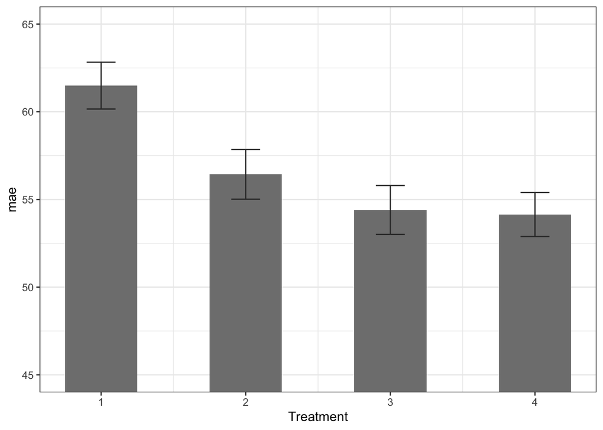

```r
# Bar plot of MAE by treatment (with standard error bars)
data %>%
  group_by(treatment) %>%
  treatment_bar(., mae, 45, 65) +
  theme_bw()
```

**Minimum effor requirement e: T1 vs T4**

- We next compare the minimum effort requirement (e) between T1 and T4 using a two-sided Wilcoxon rank-sum test.
- The null hypothesis of equal distributions is rejected ($W = 97{,}040$, $p < 0.001$).
- e is significantly higher in T1 than in T4, consistent with H2P rather than H2R.

```r
# Two-sided Wilcoxon rank-sum test
wilcox.test(
  mae ~ treatment,
  data = df_T1T4,
  exact = FALSE
)
```

```
##
##  Wilcoxon rank sum test with continuity correction
##
## data:  mae by treatment
## W = 97040, p-value = 3.743e-06
## alternative hypothesis: true location shift is not equal to 0
```

**Regression analysis for minimum effort requirement (e)**

- We estimate regression models for the minimum effort requirement (e).
- The set of explanatory variables is identical to that used in the IV regressions.

```r
# Treatment-based specifications
res_tr1 <- feols(
  mae ~ i(treatment, ref = 1),
  data = data,
  cluster = "participant"
)

res_tr2 <- feols(
  mae ~ i(treatment, ref = 1) + lossgamble + IoC + female + economics,
  data = data,
  cluster = "participant"
)

# Mechanism-based specifications
res_mech1 <- feols(
  mae ~ open * identified,
  data = data,
  cluster = ~participant
)

res_mech2 <- feols(
  mae ~ open * identified + lossgamble + IoC + female + economics,
  data = data,
  cluster = ~participant
)

# Regression table
modelsummary(
  list(
    "(1) Treatment" = res_tr1,
    "(2) Treatment" = res_tr2,
    "(3) Mechanism" = res_mech1,
    "(4) Mechanism" = res_mech2
  ),
  coef_rename = c(
    "treatment::2" = "T2",
    "treatment::3" = "T3",
    "treatment::4" = "T4",
    "lossgamble" = "Loss Aversion",
    "IoC" = "Illusion of Control",
    "female" = "Female",
    "economics" = "Economics & Management"
  ),
  coef_order = c(
    "treatment::2",
    "treatment::3",
    "treatment::4",
    "open",
    "identified",
    "open:identified",
    "lossgamble",
    "IoC",
    "female",
    "economics"
  ),
  stars = c("*" = .1, "**" = .05, "***" = .01),
  statistic = "({std.error})",
  gof_omit = "IC|Log|Adj"
)
```

|  | (1) Treatment | (2) Treatment | (3) Mechanism | (4) Mechanism |
| --- | --- | --- | --- | --- |
| (Intercept) | 61.492*** | 59.834*** | 61.492*** | 59.834*** |
|  | (2.690) | (4.063) | (2.690) | (4.063) |
| T2 | -5.060 | -5.927 |  |  |
|  | (3.993) | (4.067) |  |  |
| T3 | -7.089* | -6.527 |  |  |
|  | (4.135) | (4.288) |  |  |
| T4 | -7.348** | -7.793** |  |  |
|  | (3.561) | (3.633) |  |  |
| Loss Aversion |  | 0.656 |  | 0.656 |
|  |  | (0.798) |  | (0.798) |
| Illusion of Control |  | 0.106 |  | 0.106 |
|  |  | (0.158) |  | (0.158) |
| Female |  | -2.819 |  | -2.819 |
|  |  | (2.956) |  | (2.956) |
| Economics & Management |  | 2.453 |  | 2.453 |
|  |  | (3.425) |  | (3.425) |
| open |  |  | -5.060 | -5.927 |
|  |  |  | (3.993) | (4.067) |
| identified |  |  | -7.089* | -6.527 |
|  |  |  | (4.135) | (4.288) |
| open:identified |  |  | 4.801 | 4.661 |
|  |  |  | (5.590) | (5.664) |
| Num.Obs. | 1616 | 1576 | 1616 | 1576 |
| R2 | 0.012 | 0.020 | 0.012 | 0.020 |
| RMSE | 27.19 | 27.15 | 27.19 | 27.15 |
| Std.Errors | by: participant | by: participant | by: participant | by: participant |

* p < 0.1, ** p < 0.05, *** p < 0.01

#### 4.4 Ruling Out Alternative Explanations

- Descriptive statistics of principal/s effort level (E) by treatment, including Bartling et al. (2014)

```r
# Summary statistics by treatment
data_main_joined  %>%
  group_by(treatment) %>%
  summarise(
    mean_peffort = mean(peffort, na.rm = TRUE),
    sd_peffort   = sd(peffort, na.rm = TRUE),
    n       = sum(!is.na(peffort)),
    se_peffort   = sd_peffort / sqrt(n)
  )
```

| treatment | mean_peffort | sd_peffort | n | se_peffort |
| --- | --- | --- | --- | --- |
| 1 | 63.32936 | 22.12830 | 419 | 1.0810381 |
| 2 | 60.75711 | 23.46429 | 387 | 1.1927570 |
| 3 | 62.02619 | 23.49441 | 420 | 1.1464099 |
| 4 | 62.88462 | 20.11329 | 390 | 1.0184761 |
| Bartling et al. (2014) | 60.01739 | 23.70396 | 690 | 0.9023944 |

- Principal’s effort level (E) by treatment (Figure 4)

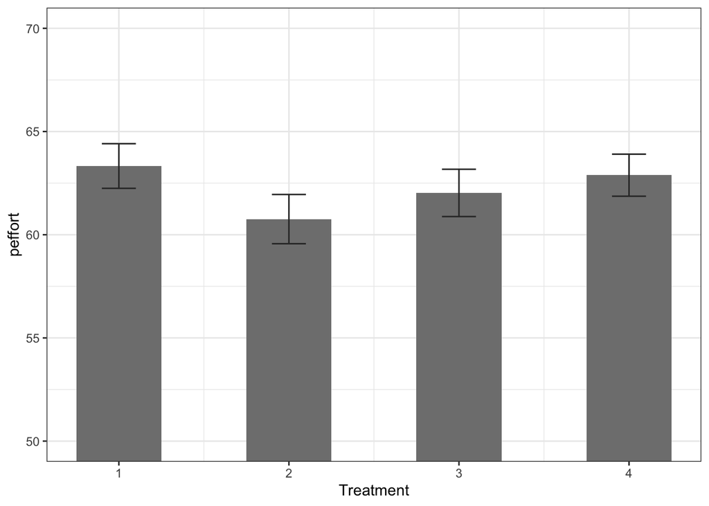

```r
# Bar plot of MAE by treatment (with standard error bars)

data %>%
  group_by(treatment) %>%
  treatment_bar(., peffort, 50, 70) +
  theme_bw()
```

**Regression analysis for principal’s effort level (E)**

- We estimate regression models for principal’s effort level (E)).
- The set of explanatory variables is identical to that used in the IV regressions.

```r
# Treatment-based specifications
res_tr1 <- feols(
  peffort ~ i(treatment, ref = 1),
  data = data,
  cluster = "participant"
)

res_tr2 <- feols(
  peffort ~ i(treatment, ref = 1) + lossgamble + IoC + female + economics,
  data = data,
  cluster = "participant"
)


# Mechanism-based specifications
res_mech1<- feols(peffort ~ open * identified,
      data = data,
      cluster = ~participant)

res_mech2<- feols(peffort ~ open * identified + lossgamble + IoC + female + economics,
      data = data,
      cluster = ~participant)

# Regression table
modelsummary(
  list(
    "(1) Treatment" = res_tr1,
    "(2) Treatment" = res_tr2,
    "(3) Mechanism" = res_mech1,
    "(4) Mechanism" = res_mech2
  ),
  coef_rename = c(
    "treatment::2" = "T2",
    "treatment::3" = "T3",
    "treatment::4" = "T4",
    "lossgamble" = "Loss Aversion",
    "IoC" = "Illusion of Control",
    "female" = "Female",
    "economics" = "Economics & Management"
  ),
  coef_order = c(
    "treatment::2",
    "treatment::3",
    "treatment::4",
    "open",
    "identified",
    "open:identified",
    "lossgamble",
    "IoC"
  ),
  stars = c("*" = .1, "**" = .05, "***" = .01),
  statistic = "({std.error})",
  gof_omit = "IC|Log|Adj"
)
```

|  | (1) Treatment | (2) Treatment | (3) Mechanism | (4) Mechanism |
| --- | --- | --- | --- | --- |
| (Intercept) | 63.329*** | 63.230*** | 63.329*** | 63.230*** |
|  | (2.291) | (3.296) | (2.291) | (3.296) |
| T2 | -2.572 | -2.915 |  |  |
|  | (3.329) | (3.337) |  |  |
| T3 | -1.303 | -1.769 |  |  |
|  | (3.080) | (3.144) |  |  |
| T4 | -0.445 | -0.443 |  |  |
|  | (3.112) | (3.245) |  |  |
| Loss Aversion |  | 0.223 |  | 0.223 |
|  |  | (0.574) |  | (0.574) |
| Illusion of Control |  | 0.206* |  | 0.206* |
|  |  | (0.119) |  | (0.119) |
| Female |  | -1.561 |  | -1.561 |
|  |  | (2.406) |  | (2.406) |
| Economics & Management |  | -2.424 |  | -2.424 |
|  |  | (3.507) |  | (3.507) |
| open |  |  | -2.572 | -2.915 |
|  |  |  | (3.329) | (3.337) |
| identified |  |  | -1.303 | -1.769 |
|  |  |  | (3.080) | (3.144) |
| open:identified |  |  | 3.431 | 4.240 |
|  |  |  | (4.444) | (4.473) |
| Num.Obs. | 1616 | 1576 | 1616 | 1576 |
| R2 | 0.002 | 0.009 | 0.002 | 0.009 |
| RMSE | 22.33 | 22.36 | 22.33 | 22.36 |
| Std.Errors | by: participant | by: participant | by: participant | by: participant |

* p < 0.1, ** p < 0.05, *** p < 0.01

- The Wald test examines whether all treatment effects (T2–T4 relative to T1) are jointly equal to zero.
- The null cannot be rejected ($p = 0.872$), indicating no overall treatment effect on effort relative to T1.

```r
wald(res_tr1, keep = "treatment")
```

```
## Wald test, H0: joint nullity of treatment::2, treatment::3 and treatment::4
##  stat = 0.234925, p-value = 0.872065, on 3 and 1,612 DoF, VCOV: Clustered (participant).
```

### Appendix A: Self-reported awareness of others

**Post-experimental questionnaire items (social awareness measures).**

- Q1: During the experiment, were you concerned about the presence or gaze of the participant sitting next to you?
- Q2: During the experiment, were you concerned about the presence or gaze of other nearby participants, excluding the one sitting next to you?
- Q3: During the experiment, were you concerned about the presence or gaze of the experiment staff?
- Q4: During the experiment, were you concerned that the experimenters would later observe data on your behavior?
- Responses were recorded on a seven-point Likert scale, where 1 indicates “not at all concerned,” 4 indicates a neutral response, and 7 indicates “very concerned.”
- All statistics are based on responses from participants in the role of principals.
- The table reports treatment-level means of each item (with standard deviations in parentheses). The rightmost column reports p-values from ANOVA tests of equality across treatments.

```r
#--------------------------
# 1. Descriptive statistics
#--------------------------
# Compute means, standard deviations, and sample sizes by treatment

desc_stats <- data %>%
  group_by(treatment) %>%
  summarise(
    q_gaze_next_mean  = mean(q_gaze_next, na.rm = TRUE),
    q_gaze_next_sd    = sd(q_gaze_next, na.rm = TRUE),
    q_gaze_next_n     = sum(!is.na(q_gaze_next)),

    q_gaze_nearby_mean  = mean(q_gaze_nearby, na.rm = TRUE),
    q_gaze_nearby_sd    = sd(q_gaze_nearby, na.rm = TRUE),
    q_gaze_nearby_n     = sum(!is.na(q_gaze_nearby)),

    q_gaze_experimenter_mean = mean(q_gaze_experimenter, na.rm = TRUE),
    q_gaze_experimenter_sd   = sd(q_gaze_experimenter, na.rm = TRUE),
    q_gaze_experimenter_n    = sum(!is.na(q_gaze_experimenter)),

    q_analyzed_by_experimenter_mean = mean(q_analyzed_by_experimenter, na.rm = TRUE),
    q_analyzed_by_experimenter_sd   = sd(q_analyzed_by_experimenter, na.rm = TRUE),
    q_analyzed_by_experimenter_n    = sum(!is.na(q_analyzed_by_experimenter)),

    .groups = "drop"
  )

#--------------------------
# 2. ANOVA
#--------------------------
# Test whether treatment differences are statistically significant

anova_q_gaze_next <- summary(aov(q_gaze_next ~ factor(treatment), data = data))
anova_q_gaze_nearby <- summary(aov(q_gaze_nearby ~ factor(treatment), data = data))
anova_q_gaze_experimenter <- summary(aov(q_gaze_experimenter ~ factor(treatment), data = data))
anova_q_analyzed_by_experimenter <- summary(aov(q_analyzed_by_experimenter ~ factor(treatment), data = data))

# Extract p-values
p_q_gaze_next <- anova_q_gaze_next[[1]]["factor(treatment)", "Pr(>F)"]
p_q_gaze_nearby <- anova_q_gaze_nearby[[1]]["factor(treatment)", "Pr(>F)"]
p_q_gaze_experimenter <- anova_q_gaze_experimenter[[1]]["factor(treatment)", "Pr(>F)"]
p_q_analyzed_by_experimenter <- anova_q_analyzed_by_experimenter[[1]]["factor(treatment)", "Pr(>F)"]

#--------------------------
# 3. Appendix table: means
#--------------------------
# Prepare treatment-level means for each variable

appendix_means <- data %>%
  group_by(treatment) %>%
  summarise(
    q_gaze_next = mean(q_gaze_next, na.rm = TRUE),
    q_gaze_nearby = mean(q_gaze_nearby, na.rm = TRUE),
    q_gaze_experimenter = mean(q_gaze_experimenter, na.rm = TRUE),
    q_analyzed_by_experimenter = mean(q_analyzed_by_experimenter, na.rm = TRUE),
    .groups = "drop"
  ) %>%
  pivot_longer(
    cols = c(q_gaze_next, q_gaze_nearby, q_gaze_experimenter, q_analyzed_by_experimenter),
    names_to = "variable",
    values_to = "mean"
  ) %>%
  mutate(treatment = paste0("T", treatment)) %>%
  pivot_wider(
    names_from = treatment,
    values_from = mean
  )

#--------------------------
# 4. Appendix table: standard deviations
#--------------------------
# Prepare treatment-level standard deviations

appendix_sds <- data %>%
  group_by(treatment) %>%
  summarise(
    q_gaze_next = sd(q_gaze_next, na.rm = TRUE),
    q_gaze_nearby = sd(q_gaze_nearby, na.rm = TRUE),
    q_gaze_experimenter = sd(q_gaze_experimenter, na.rm = TRUE),
    q_analyzed_by_experimenter = sd(q_analyzed_by_experimenter, na.rm = TRUE),
    .groups = "drop"
  ) %>%
  pivot_longer(
    cols = c(q_gaze_next, q_gaze_nearby, q_gaze_experimenter, q_analyzed_by_experimenter),
    names_to = "variable",
    values_to = "sd"
  ) %>%
  mutate(treatment = paste0("T", treatment)) %>%
  pivot_wider(
    names_from = treatment,
    values_from = sd,
    names_prefix = "sd_"
  )

#--------------------------
# 5. Appendix table: p-values
#--------------------------
# Store ANOVA p-values

appendix_p <- data.frame(
  variable = c("q_gaze_next", "q_gaze_nearby", "q_gaze_experimenter", "q_analyzed_by_experimenter"),
  p_value = c(p_q_gaze_next, p_q_gaze_nearby, p_q_gaze_experimenter, p_q_analyzed_by_experimenter)
)

#--------------------------
# 6. Final appendix table
#--------------------------
# Combine means, standard deviations, and p-values

appendix_table <- appendix_means %>%
  left_join(appendix_sds, by = "variable") %>%
  left_join(appendix_p, by = "variable") %>%
  mutate(
    variable = recode(variable,
      "q_gaze_next" = "Q1",
      "q_gaze_nearby" = "Q2",
      "q_gaze_experimenter" = "Q3",
      "q_analyzed_by_experimenter" = "Q4"
    ),
    T1 = paste0(round(T1, 2), " (", round(sd_T1, 2), ")"),
    T2 = paste0(round(T2, 2), " (", round(sd_T2, 2), ")"),
    T3 = paste0(round(T3, 2), " (", round(sd_T3, 2), ")"),
    T4 = paste0(round(T4, 2), " (", round(sd_T4, 2), ")"),
    p_value = round(p_value, 3)
  ) %>%
  select(variable, T1, T2, T3, T4, p_value)

appendix_table
```

| variable | T1 | T2 | T3 | T4 | p_value |
| --- | --- | --- | --- | --- | --- |
| Q1 | 2.12 (1.54) | 2.27 (1.78) | 1.95 (1.4) | 2.36 (1.77) | 0.003 |
| Q2 | 1.95 (1.31) | 1.98 (1.59) | 1.69 (1.12) | 2.17 (1.76) | 0.000 |
| Q3 | 2.43 (1.76) | 2.76 (1.86) | 2.38 (1.68) | 2.17 (1.5) | 0.000 |
| Q4 | 2.19 (1.57) | 2.21 (1.53) | 2 (1.5) | 1.89 (1.2) | 0.005 |